# Assignment_2

22 March 2018

```r
library(tidyverse)
survey <- read_csv("data/survey.csv")
```

Tidying the data:

```r
survey1 <- survey[1:63,] %>%
  mutate(
    Q1 = case_when(
      Q1 == "A" ~ "1",
      Q1 == "B" ~ "2",
      Q1 == "C" ~ "3",
      Q1 == "D" ~ "4",
      TRUE ~ "Other"),

    Q2 = case_when(
      Q2 == "three times\n" ~ NA_character_,
      Q2 == "1/2" ~ "0.5",
      Q2 == "4\n" ~ "4",
      Q2 == "5hrs" ~ "5",
      Q2 == "2 hours" ~ "2",
      Q2 == "2 hours ( to uni)"~ "2",
      Q2 == "3 hours" ~ "3",
      Q2 == "0.5 hours" ~ "0.5",
      Q2 == "20HOUR" ~ NA_character_,
      Q2 == "120" ~ NA_character_,
      Q2 == "30" ~ NA_character_,
      Q2 == "10" ~ NA_character_,
      Q2 == "14" ~ NA_character_,
      Q2 == "9" ~ NA_character_,
      Q2 == "8" ~ NA_character_,
      Q2 == "25" ~ NA_character_,
      Q2 == "4/7" ~ NA_character_,
      Q2 == "20" ~ NA_character_,
      Q2 == "12" ~ NA_character_,
      TRUE ~ Q2),

    Q4 = case_when(
      Q4 == "Anything" ~ NA_character_,
      Q4 == "Depression" ~ NA_character_,
      Q4 == "light\n" ~ NA_character_,
      Q4 == "music" ~ NA_character_,
      Q4 == "-" ~ NA_character_,
      Q4 == "Pop music" ~ "Pop",
      Q4 == "K-pop" ~ "Asian-Pop",
      Q4 == "K-Pop" ~ "Asian-Pop",
      Q4 == "alt rock" ~ "Alternative Rock",
      Q4 == "classical" ~ "Classical",
      Q4 == "country music" ~ "Country Music",
      Q4 == "hip-hop" ~ "Hip-Hop",
      Q4 == "Hiphop" ~ "Hip-Hop",
      Q4 == "hip-pop" ~ "Hip-Hop",
      Q4 == "hip hop" ~ "Hip-Hop",
      Q4 == "jazz" ~ "Jazz",
      Q4 == "mandopop" ~ "Asian-Pop",
      Q4 == "pop" ~ "Pop",
      Q4 == "pop music" ~ "Pop",
      Q4 == "popular" ~ "Pop",
      Q4 == "rnb" ~ "R&B",
      Q4 == "RnB" ~ "R&B",
      Q4 == "RNB" ~ "R&B",
      Q4 == "Rock and/or Roll" ~ "Rock",
      TRUE ~ Q4),

    Q5 = case_when(
      Q5 == "40hrs" ~ "40",
      Q5 == "24 Hours" ~ "24",
      Q5 == "40 hours" ~ "40",
      Q5 == "35 hours" ~ "35",
      Q5 == "Choosing not to answer" ~ NA_character_,
      Q5 == "-" ~ NA_character_,
      Q5 == "24HOUR" ~ "24",
      Q5 == "6 hours" ~ "6",
      Q5 == "24 Hours\n" ~ "24",
      Q5 =="72\n" ~ "72",
      TRUE ~ Q5),

    Q6 = case_when(
      Q6 == "speed"~"Super-speed",
      Q6 == "forecasting\n" ~ "Predict the future",
      Q6 == "teleporting" ~ "Teleportation",
      Q6 == "teleportation" ~ "Teleportation",
      Q6 == "go back to a past time" ~ "Time travel",
      Q6 == "predict the future" ~ "Predict the future",
      Q6 == "flying" ~ "Flying",
      Q6 == "Flight"~ "Flying",
      Q6 == "have another super power" ~ "Have another super power",
      Q6 == "fly"~ "Flying",
      Q6 == "I don't need any super power." ~ "None",
      Q6 == "time control" ~ "Freeze time",
      Q6 == "to never have to sleep" ~ "To never have to sleep",
      Q6 == "forecast the future" ~ "Predict the future",
      Q6 == "remember everything I saw" ~ "Perfect memory",
      Q6 == "time travel" ~ "Time travel",
      Q6 == "Time-Reverse" ~ "Time travel",
      Q6 == "invisibility" ~ "Invisibility",
      Q6 == "freeze time" ~ "Freeze time",
      Q6 == "Control Time" ~ "Freeze time",
      Q6 == "fire" ~ "Fire powers",
      Q6 == "Never forget" ~ "Perfect memory",
      Q6 == "invisible" ~ "Invisibility",
      Q6 == "Invisible" ~ "Invisibility",
      Q6 == "Magic like Dr Strange" ~ "Magic",
      Q6 == "Fly" ~ "Flying",
      Q6 == "Not needing sleep" ~ "To never have to sleep",
      Q6 == "time" ~ "Time travel",
      Q6 == "can go to wherever i want in any time" ~ "Teleportation",
      Q6 == "imortality" ~ "Imortality",
      Q6 == "Nothing" ~ "None",
      TRUE ~ Q6),

    Q7 = case_when(
      Q7 == "A" ~ "two sizes too big",
      Q7 == "B" ~ "one size too small",
      Q7 == "C" ~ "neither of these"),

    Q8 = case_when(
      Q8 == "A" ~ "[0,3)",
      Q8 == "B" ~ "[3,6)",
      Q8 == "C" ~ "[6,9)",
      Q8 == "D" ~ "[9,12)",
      Q8 == "E" ~ "More than 12"),

    Q9 = case_when(
      Q9 == "n/a" ~ "None",
      Q9 == "no idea"~"None",
      Q9=="None"~"None",
      Q9=="No television"~"None",
      Q9=="I do not watch television."~"None",
      Q9=="I don't watch television."~"None",
      Q9=="Nothing"~"None",
      Q9=="none"~"None",
      Q9=="i don't watch tv"~"None",
      Q9=="non"~"None",
      Q9=="dont watch tv" ~ "None",
      Q9 == "no idea\n" ~"None" ,
      Q9 =="stream.tv\n" ~ "Uncertified online service",
      Q9 == "reality show" ~ "None",
      Q9=="phone" ~ "Uncertified online service" ,
      Q9 == "watchseries" ~ "Uncertified online service",
      Q9 == "Netlfix" ~ "Netflix",
      Q9 == "netflix" ~"Netflix",
      Q9 == "Don't watch television" ~"None",
      Q9=="internet"~"Uncertified online service",
      Q9=="pc"~"Uncertified online service",
      Q9=="I don't" ~"None",
      Q9=="Netflix & Stan"~"Netflix",
      Q9=="dont watch"~"None",
      Q9=="Foxtel..."~"Uncertified online service",
      Q9=="youtube"~"Youtube",
      Q9=="tivo"~"Uncertified online service",
      Q9 =="optus" ~ "Optus",
      Q9=="Kodi"~"Uncertified online service",
      Q9=="Crunchyroll"~"Uncertified online service",
      Q9=="hdonline.is"~"Uncertified online service",
      Q9=="I don't watch television\n"~"None",
      Q9=="stan" ~ "Stan",
      Q9=="youtube, netflix" ~ "Youtube",
      TRUE ~ Q9),

    Q10 = case_when(
      Q10 == "?" ~ NA_character_,
      Q10 == "1\n" ~ "1",
      TRUE ~ Q10),

    Q11 = case_when(
      Q11 == "A" ~ "elective",
      Q11 == "B" ~ "core"),

    Q12 = case_when(
      Q12 == "A" ~ "single",
      Q12 == "B" ~ "double"),

    Q13 = if_else(Q13 == "$30", "30", Q13),
    Q13 = if_else(Q13 == "$5", "5", Q13),
    Q13 = if_else(Q13 == "$15", "15", Q13),
    Q13 = if_else(Q13 == "35 dollars", "35", Q13),
    Q13 = if_else(Q13 == "$35", "35", Q13),

    Q14 = case_when(
      Q14 == "A" ~ "0",
      Q14 == "B" ~ "1",
      Q14 == "C" ~ "2",
      Q14 == "D" ~ "3",
      Q14 == "E" ~ "4",
      Q14 == "F" ~ "5",
      Q14 == "G" ~ "more than 5"),

    Q15 = case_when(
      Q15 == "A" ~ "cucumbers",
      Q15 == "B" ~ "carrots",
      Q15 == "C" ~ "neither"),

    Q16 = case_when(
      Q16 == "F" ~"Other",
      Q16 == "A" ~ "Dog",
      Q16 == "B" ~ "Cat",
      Q16 == "C" ~ "Rabbit",
      Q16 == "D" ~ "Bird",
      Q16 == "E" ~ "Reptile",
      Q16 == "A, B" ~ "Multiple",
      Q16 == "A, C" ~ "Multiple",
      Q16 == "B, D, E" ~ "Multiple",
      Q16 == "A, B, D" ~ "Multiple",
      Q16 == "A, E" ~ "Multiple",
      Q16 == "A, D, F" ~ "Multiple",
      Q16 == "E, F" ~ "Multiple",
      TRUE ~ Q16),

    Q17 = case_when(
      Q17 == "A" ~ "yes",
      Q17 == "B" ~ "no"),

    Q18 = case_when(
      Q18 == "listen to music" ~ "Music",
      Q18 == "sport" ~ "Sport",
      Q18 == "Basketball" ~ "Sport",
      Q18 == "watch youtube\n" ~ "Youtube",
      Q18 == "watch vedio" ~ "Youtube",
      Q18 == "internet, stretch, water" ~ "Social media",
      Q18 == "cook" ~ "Cook",
      Q18 == "sleep" ~ "Sleep",
      Q18 == "youtube" ~ "Youtube",
      Q18 == "gaming" ~ "Gaming",
      Q18 == "To listen music" ~ "Music",
      Q18 == "training my aim in different FPS games." ~ "Gaming",
      Q18 == "Play games" ~ "Gaming",
      Q18 == "social media" ~ "Social media",
      Q18 == "video game" ~ "Gaming",
      Q18 == "watch tv" ~ "TV",
      Q18 == "Games" ~ "Gaming",
      Q18 == "gym\ninternet surfing" ~ "Gym",
      Q18 == "computer games" ~ "Gaming",
      Q18 == "play games"~"Gaming",
      Q18 == "Instagram" ~ "Social media",
      Q18 == "Game" ~ "Gaming",
      Q18 == "league of legends" ~ "Gaming",
      Q18 == "the office" ~ "TV",
      Q18 == "Read, Play Guitar, Electronics, Sport" ~ "Read",
      Q18 == "This is us and cry" ~ "TV",
      Q18 == "Swim, cook" ~ "Sport",
      Q18 == "tv" ~ "TV",
      Q18 == "Have a trip\n" ~ "Have a trip",
      Q18 == "piano" ~ "Piano",
      Q18 == "Play video games" ~ "Gaming",
      Q18 == "Study more" ~ "Study",
      Q18 == "listen music" ~ "Music",
      Q18 == "Watch Something/ Light Exercise" ~ "TV",
      Q18 == "play my phone" ~ "Social media",
      Q18 == "work" ~ "Work",
      Q18 == "Your mum" ~ NA_character_,
      TRUE ~ Q18),

    Q19 = case_when(
      Q19 == "A" ~ "Windows",
      Q19 == "B" ~ "Mac",
      Q19 == "C" ~ "Linux",
      Q19 == "D" ~ "Other"),

    Q21 = if_else(Q21 == "7;30", "7.5", Q21),

    Q22 = if_else(Q22 == "3days", "3", Q22),

    Q23 = if_else(Q23 == "1997", "20", Q23),
    Q23 = if_else(Q23 == "XXI", "21", Q23),

    Q24 = case_when(
      Q24 == "I don't know" ~ NA_character_, TRUE ~ Q24),

    Q25 = case_when(
      Q25 == "afl" ~ "AFL",
      Q25 == "badminton" ~ "Badminton",
      Q25 == "basketball" ~ "Basketball",
      Q25 == "Electronic games and running" ~ "Running",
      Q25 == "equestrian" ~ "Equestrian",
      Q25 == "European Handball" ~ "European handball",
      Q25 == "Football" ~ "Soccer",
      Q25 == "soccer" ~ "Soccer",
      Q25 == "motorsport" ~ "Motorsport",
      Q25 == "netball" ~ "Netball",
      Q25 == "rowing" ~ "Rowing",
      Q25 == "running" ~ "Running",
      Q25 == "skiing" ~ "Skiing",
      Q25 == "sleep" ~ "Sleep",
      Q25 == "swim" ~ "Swimming",
      Q25 == "swimming" ~ "Swimming",
      Q25 == "swimming\n" ~ "Swimming",
      Q25 == "tennis" ~ "Tennis",
      Q25 == "Table Tennis" ~ "Table tennis",
      Q25 == "mma" ~ "MMA",
      Q25 == "Choosing not to answer" ~ NA_character_,
      Q25 == "Yes" ~ NA_character_, TRUE ~ Q25 ),

    Q26 = case_when(
      Q26 == "A" ~ "Female",
      Q26 == "B" ~ "Male",
      Q26 == "C" ~ "Perfer not to answer"),

    Q27 = case_when(
      Q27 == "A" ~ "Fridge",
      Q27 == "B" ~ "Pantry"),

    Q28 = case_when(
      Q28 == "A" ~ "0",
      Q28 == "B" ~ "1-5",
      Q28 == "C" ~ "6-10",
      Q28 == "D" ~ "10-20",
      Q28 == "E" ~ "More than 20"),

    Q29 = case_when(
      Q29 == "A" ~ "Yes",
      Q29 == "B" ~ "No"),

    Q30 = case_when(
      Q30 == "A" ~ "No",
      Q30 == "B" ~ "Yes"),

    Q31 = case_when(
      Q31 == "A" ~ "Yes",
      Q31 == "B" ~ "No"),

    Q32 = case_when(
      Q32 == "wok" ~ "Wok",
      Q32 == "whisk" ~ "Whisk",
      Q32 == "tongs" ~ "Tongs",
      Q32 == "That thing that cuts eggs" ~ "Egg cutter",
      Q32 == "spoon" ~ "Spoon",
      Q32 == "a spoon" ~ "Spoon",
      Q32 == "spork" ~ "Spork",
      Q32 == "spatula" ~ "Spatula",
      Q32 == "sharper" ~ "Sharper",
      Q32 == "refrigerator" ~ "Refrigerator",
      Q32 == "Fridge" ~ "Refrigerator",
      Q32 == "pot" ~ "Pot",
      Q32 == "pan" ~ "Pan",
      Q32 == "oven" ~ "Oven",
      Q32 == "IKEA soup ladle" ~ "Ladle",
      Q32 == "knife" ~ "Knife",
      Q32 == "fork" ~ "Fork",
      Q32 == "dish washer" ~ "Dish washer",
      Q32 == "colander" ~ "Colander",
      Q32 == "Coffee machine" ~ "Coffee Machine",
      Q32 == "coffee cup" ~ "Coffee cup",
      Q32 == "chopstick(s)" ~ "Chopsticks",
      Q32 == "None" ~ NA_character_,
      Q32 == "someone can eat" ~ NA_character_, TRUE ~ Q32)
    )
```

Converting each column within the data frame to be the right data type.

```r
survey2 <- survey1 %>%
  mutate(
    Q2 = as.numeric(Q2),
    Q3 = as.logical(Q3),
    Q5 = as.numeric(Q5),
    Q10 = as.numeric(Q10),
    Q13 = as.numeric(Q13),
    Q20 = as.logical(Q20),
    Q21 = as.numeric(Q21),
    Q22 = as.integer(Q22),
    Q23 = as.integer(Q23),
    Q24 = as.numeric(Q24),
    Q33 = as.logical(Q33),
         )
```

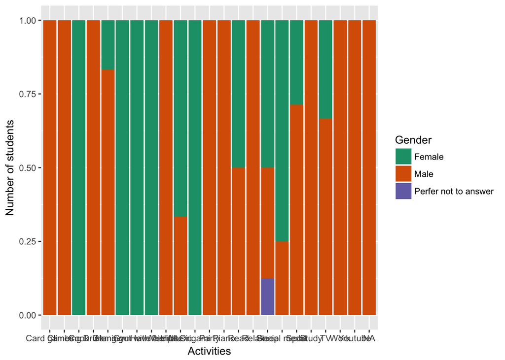

```r
ggplot(survey2,aes(x=Q18,fill=Q26))+
  geom_bar(position = "fill") +
  scale_fill_brewer(palette="Dark2")+
  labs(fill="Gender")+
  xlab("Activities") + ylab("Number of students")
```

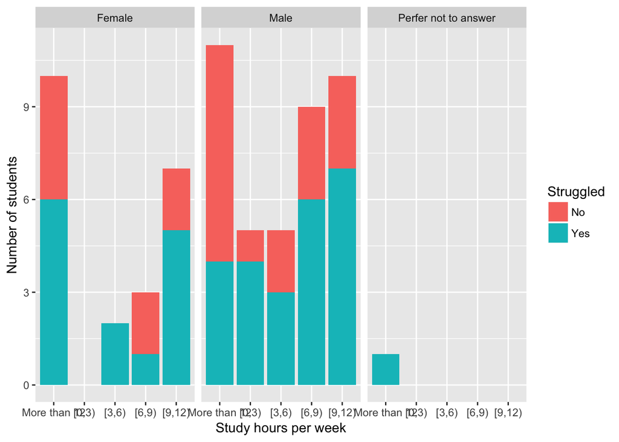

```r
ggplot(survey2,aes(x=Q8,fill=Q30))+
  geom_bar()+
  facet_grid(~Q26)+
  labs(fill="Struggled")+
  xlab ("Study hours per week")+ ylab("Number of students")
```

According to the graph, students who spend more than 12 hours a week in studying are less likely to struggle in this unit. This means porblem in this unit can be solved by hard working. Additionally, the proportion of confused students are approximately the same between males and females. So it is not reliable to say that males are good at computing.

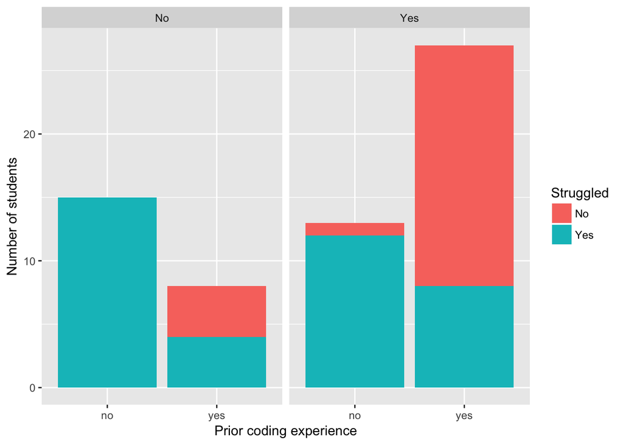

```r
ggplot(survey2,aes(x=Q17,fill=Q30)) +
  geom_bar() +
  facet_grid(~Q31)+
  labs(fill="Struggled")+
  xlab( "Prior coding experience")+ylab("Number of students")
```

Obviously, students who have previous experience on coding are less likely to have problems in this unit.

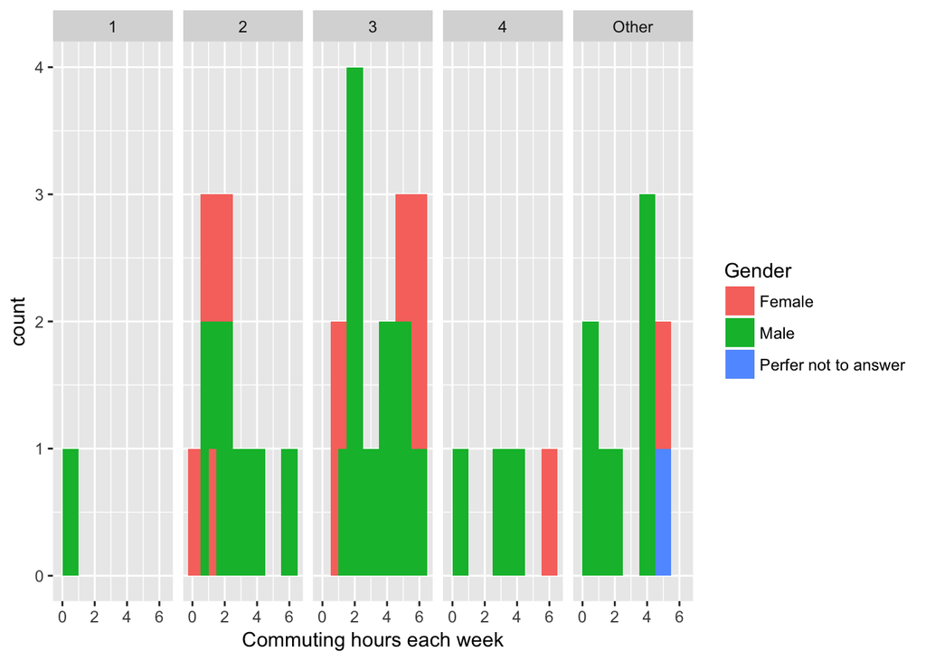

```r
ggplot(survey2, aes(x = Q2, fill = Q26))+
   geom_bar(width = 1)+
   facet_grid(~ Q1)+
  labs(fill="Gender")+
  xlab("Commuting hours each week")
```

The relationship between the amount people spended in communicating with Uni and their year of uni, people who are second or third year of uni will spend more time to communicate with uni

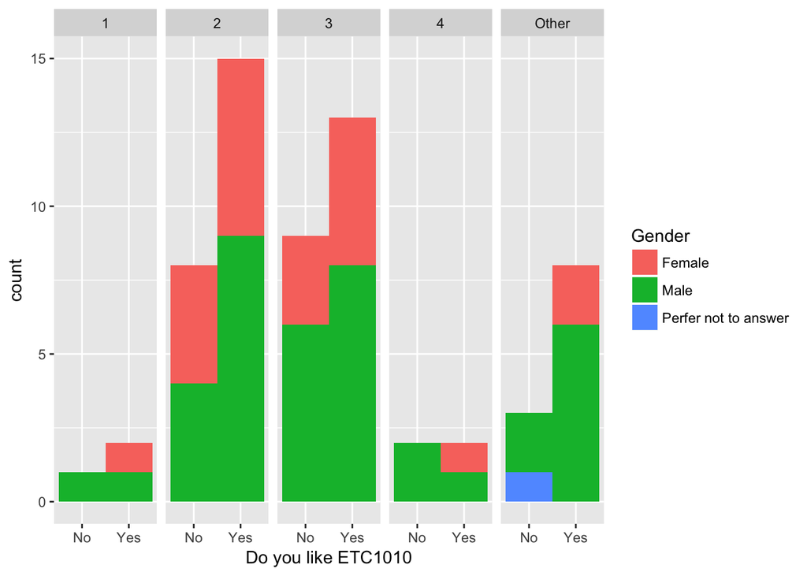

```r
ggplot(survey2, aes(x = Q31, fill = Q26))+
  geom_bar(width = 1)+
  facet_grid(~ Q1)+
  labs(fill="Gender")+
  xlab("Do you like ETC1010")
```

The relationship between whether people like the subject and their year of uni, people who are forth year of uni are eaually likely to like this subject, people in the other stages are more likely to like this subject

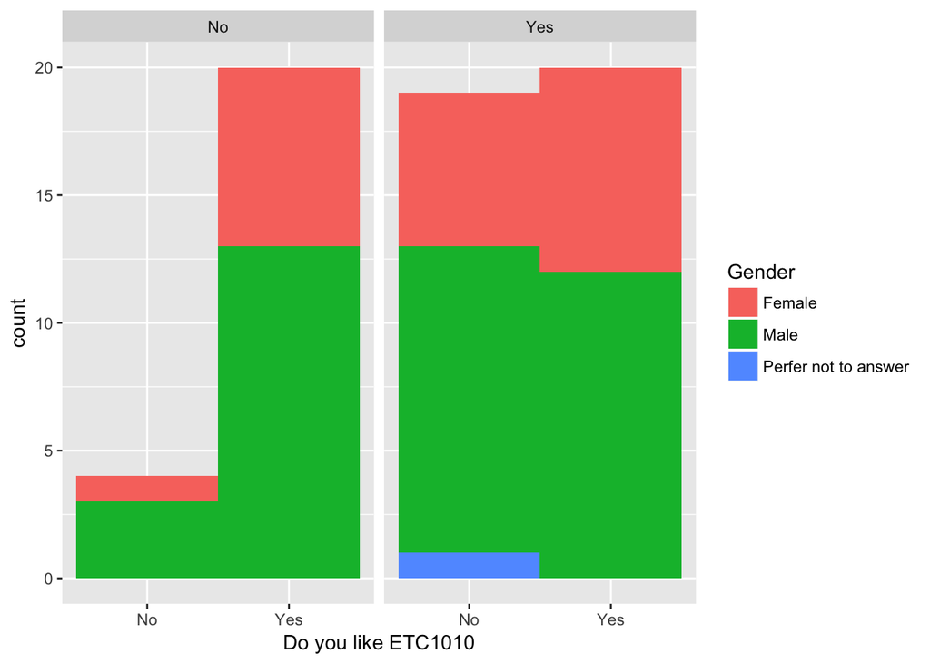

```r
ggplot(survey2, aes(x = Q31, fill = Q26))+
  geom_bar(width = 1)+
  facet_grid(~ Q30)+
  labs(fill="Gender")+
  xlab("Do you like ETC1010")
```

The relationship about the study situation of people and their study attitude to this subject, people who are good at this subject is more likely to like this subject

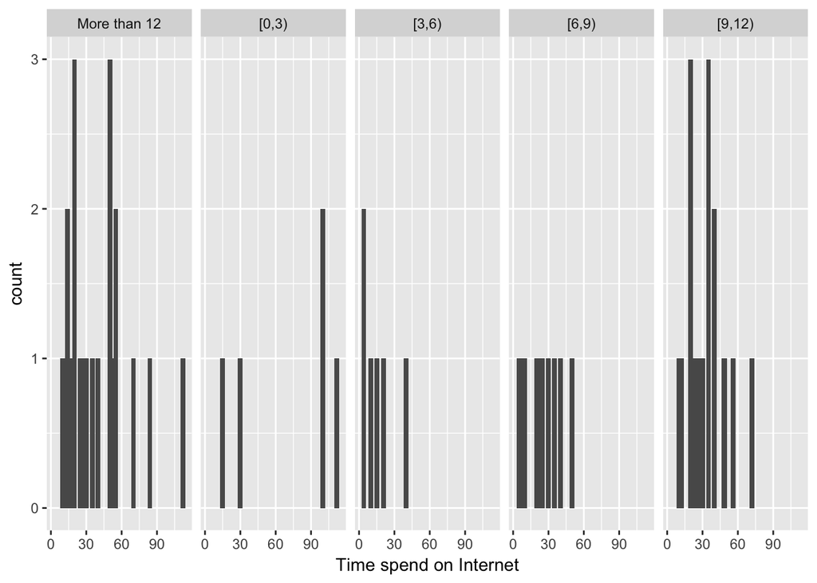

```r
ggplot(survey2, aes(x = Q5))+
  geom_bar(width = 4)+
  facet_grid(~ Q8)+
  xlab("Time spend on Internet")
```

The relationship about the time people spend to studying and spend on the internet, there is no clear relation ship between the time they spend on studying and internet.